# Let's start by importing the libraries

```python
#Importing NumPY and Pandas Library
import numpy as np
import pandas as pd
```

```python
#Importing Data Visualization Libraries
import matplotlib.pyplot as plt
import seaborn as sns
%matplotlib inline
```

### Read the dataset

```python
result = pd.read_csv("StudentsPerformance.csv")
```

# Let's start exploring the data

```python
result.head()
```

|  | gender | race/ethnicity | parental level of education | lunch | test preparation course | math score | reading score | writing score |
| --- | --- | --- | --- | --- | --- | --- | --- | --- |
| 0 | female | group B | bachelor's degree | standard | none | 72 | 72 | 74 |
| 1 | female | group C | some college | standard | completed | 69 | 90 | 88 |
| 2 | female | group B | master's degree | standard | none | 90 | 95 | 93 |
| 3 | male | group A | associate's degree | free/reduced | none | 47 | 57 | 44 |
| 4 | male | group C | some college | standard | none | 76 | 78 | 75 |

### Lets change the column name according to our convenience

```python
result.columns = map(str.upper, result.columns)
result.head()
```

|  | GENDER | RACE/ETHNICITY | PARENTAL LEVEL OF EDUCATION | LUNCH | TEST PREPARATION COURSE | MATH SCORE | READING SCORE | WRITING SCORE |
| --- | --- | --- | --- | --- | --- | --- | --- | --- |
| 0 | female | group B | bachelor's degree | standard | none | 72 | 72 | 74 |
| 1 | female | group C | some college | standard | completed | 69 | 90 | 88 |
| 2 | female | group B | master's degree | standard | none | 90 | 95 | 93 |
| 3 | male | group A | associate's degree | free/reduced | none | 47 | 57 | 44 |
| 4 | male | group C | some college | standard | none | 76 | 78 | 75 |

### Checking the type of data in each column

```python
result.info()
```

```
<class 'pandas.core.frame.DataFrame'>
RangeIndex: 1000 entries, 0 to 999
Data columns (total 8 columns):
 #   Column                       Non-Null Count  Dtype
---  ------                       --------------  -----
 0   GENDER                       1000 non-null   object
 1   RACE/ETHNICITY               1000 non-null   object
 2   PARENTAL LEVEL OF EDUCATION  1000 non-null   object
 3   LUNCH                        1000 non-null   object
 4   TEST PREPARATION COURSE      1000 non-null   object
 5   MATH SCORE                   1000 non-null   int64
 6   READING SCORE                1000 non-null   int64
 7   WRITING SCORE                1000 non-null   int64
dtypes: int64(3), object(5)
memory usage: 62.6+ KB
```

### Let's check for null values in each column

```python
result.isna().sum()
```

```
GENDER                         0
RACE/ETHNICITY                 0
PARENTAL LEVEL OF EDUCATION    0
LUNCH                          0
TEST PREPARATION COURSE        0
MATH SCORE                     0
READING SCORE                  0
WRITING SCORE                  0
dtype: int64
```

### Statistical Analysis on the data

```python
result.describe()
```

|  | MATH SCORE | READING SCORE | WRITING SCORE |
| --- | --- | --- | --- |
| count | 1000.00000 | 1000.000000 | 1000.000000 |
| mean | 66.08900 | 69.169000 | 68.054000 |
| std | 15.16308 | 14.600192 | 15.195657 |
| min | 0.00000 | 17.000000 | 10.000000 |
| 25% | 57.00000 | 59.000000 | 57.750000 |
| 50% | 66.00000 | 70.000000 | 69.000000 |
| 75% | 77.00000 | 79.000000 | 79.000000 |
| max | 100.00000 | 100.000000 | 100.000000 |

#### The lowest marks in Math is 0, in Reading is 17, and writing is 10 !

#### The highest in all the 3 subjects is 100 !

### Lets analyse the marks of the students in Math, Reading and Writing

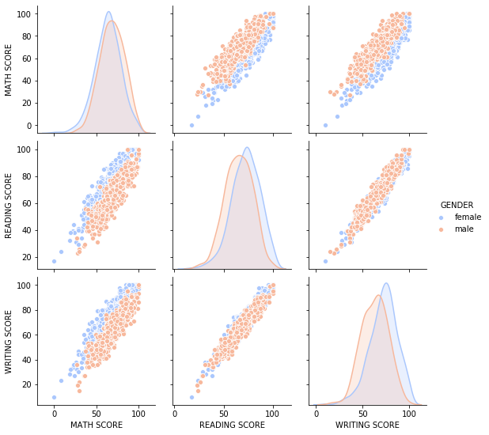

```python
sns.pairplot(result, hue = 'GENDER', palette = 'coolwarm')
```

### Heatmap for our data

```python
# Matrix form for correlation data
result.corr()
```

|  | MATH SCORE | READING SCORE | WRITING SCORE |
| --- | --- | --- | --- |
| MATH SCORE | 1.000000 | 0.817580 | 0.802642 |
| READING SCORE | 0.817580 | 1.000000 | 0.954598 |
| WRITING SCORE | 0.802642 | 0.954598 | 1.000000 |

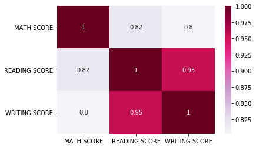

```python
sns.heatmap(result.corr(), cmap = 'PuRd', annot = True)
```

#### We can interpret that reading and writing score are highly correlated, while the writing score and math score is the least, compared to others!

### Lets add an "AVERAGE" column to the dataset

```python
result["AVERAGE"] = (result["MATH SCORE"] + result["READING SCORE"] + result["WRITING SCORE"])/3
```

```python
result.head()
```

|  | GENDER | RACE/ETHNICITY | PARENTAL LEVEL OF EDUCATION | LUNCH | TEST PREPARATION COURSE | MATH SCORE | READING SCORE | WRITING SCORE | AVERAGE |
| --- | --- | --- | --- | --- | --- | --- | --- | --- | --- |
| 0 | female | group B | bachelor's degree | standard | none | 72 | 72 | 74 | 72.666667 |
| 1 | female | group C | some college | standard | completed | 69 | 90 | 88 | 82.333333 |
| 2 | female | group B | master's degree | standard | none | 90 | 95 | 93 | 92.666667 |
| 3 | male | group A | associate's degree | free/reduced | none | 47 | 57 | 44 | 49.333333 |
| 4 | male | group C | some college | standard | none | 76 | 78 | 75 | 76.333333 |

### Lets find out the relation between Reading and Writing Score

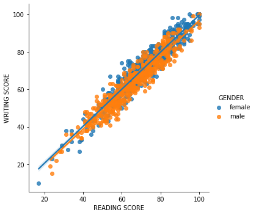

```python
sns.lmplot(x='READING SCORE',y='WRITING SCORE',data=result,hue='GENDER')
```

### Let's find out how Gender affects Ethnicity and Math Scores

```python
result.pivot_table(values='MATH SCORE',index='GENDER',columns='RACE/ETHNICITY')
```

| RACE/ETHNICITY GENDER | group A | group B | group C | group D | group E |
| --- | --- | --- | --- | --- | --- |
| female | 58.527778 | 61.403846 | 62.033333 | 65.248062 | 70.811594 |
| male | 63.735849 | 65.930233 | 67.611511 | 69.413534 | 76.746479 |

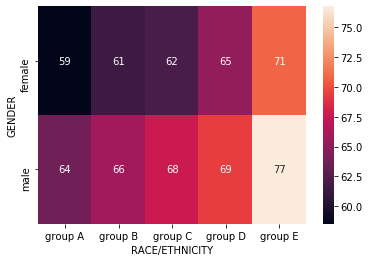

```python
pvresult = result.pivot_table(values='MATH SCORE',index='GENDER',columns='RACE/ETHNICITY')
sns.heatmap(pvresult, annot = True)
```

#### We can see that Group E Males have the highest average Math Scores, while Group A Females have the least!

### Similarly lets analyse for Reading Scores

```python
result.pivot_table(values='READING SCORE',index='GENDER',columns='RACE/ETHNICITY')
```

| RACE/ETHNICITY GENDER | group A | group B | group C | group D | group E |
| --- | --- | --- | --- | --- | --- |
| female | 69.000000 | 71.076923 | 71.944444 | 74.046512 | 75.840580 |
| male | 61.735849 | 62.848837 | 65.424460 | 66.135338 | 70.295775 |

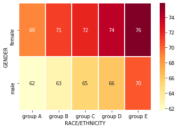

```python
pvresult = result.pivot_table(values='READING SCORE',index='GENDER',columns='RACE/ETHNICITY')
sns.heatmap(pvresult,cmap='YlOrRd',linecolor='white',linewidths=1, annot = True)
```

#### We can see that Group E females on an average, fair better than others in Reading!

### Now, for Writing Scores

```python
result.pivot_table(values='WRITING SCORE',index='GENDER',columns='RACE/ETHNICITY')
```

| RACE/ETHNICITY GENDER | group A | group B | group C | group D | group E |
| --- | --- | --- | --- | --- | --- |
| female | 67.861111 | 70.048077 | 71.777778 | 75.023256 | 75.536232 |
| male | 59.150943 | 60.220930 | 62.712230 | 65.413534 | 67.394366 |

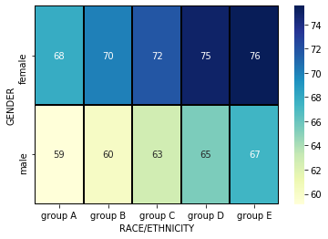

```python
pvresult = result.pivot_table(values='WRITING SCORE',index='GENDER',columns='RACE/ETHNICITY')
sns.heatmap(pvresult, cmap = 'YlGnBu',linecolor='black',linewidths=1, annot = True)
```

#### We can interpret that Group A Males have the least writing skills while Group E females have the most!

### Lets analyse the average scores now

```python
result.pivot_table(values='AVERAGE',index='GENDER',columns='RACE/ETHNICITY')
```

| RACE/ETHNICITY GENDER | group A | group B | group C | group D | group E |
| --- | --- | --- | --- | --- | --- |
| female | 65.129630 | 67.509615 | 68.585185 | 71.439276 | 74.062802 |
| male | 61.540881 | 63.000000 | 65.249400 | 66.987469 | 71.478873 |

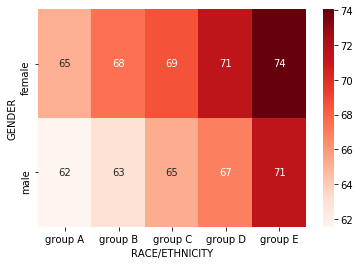

```python
pvresult = result.pivot_table(values='AVERAGE',index='GENDER',columns='RACE/ETHNICITY')
sns.heatmap(pvresult, cmap = 'Reds', annot = True)
```

#### On an average, we can say that Group E Females score the best, while Group A males, least!

### Lets see the percentage distribution of Males and Females in the Dataset

```python
(result.GENDER.value_counts()/len(result)) * 100
```

```
female    51.8
male      48.2
Name: GENDER, dtype: float64
```

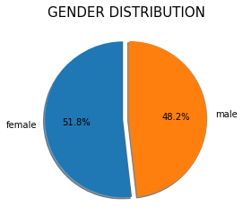

```python
gender = result['GENDER'].value_counts()
labels = result.GENDER.unique()
plt.pie(gender,labels=labels,autopct="%1.1f%%",shadow=True,explode=(0.04,0.04),startangle=90)
plt.title('GENDER DISTRIBUTION',fontsize=15)
plt.show()
```

```python
result.GENDER.value_counts()
```

```
female    518
male      482
Name: GENDER, dtype: int64
```

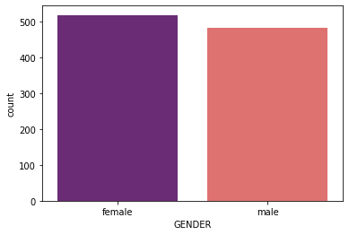

```python
sns.countplot(x='GENDER', data=result, palette = 'magma')
```

#### We can see that the gender distribution is almost 50-50 !

```python
gender = result.groupby("GENDER")
gender.mean()
```

| GENDER | MATH SCORE | READING SCORE | WRITING SCORE | AVERAGE |
| --- | --- | --- | --- | --- |
| female | 63.633205 | 72.608108 | 72.467181 | 69.569498 |
| male | 68.728216 | 65.473029 | 63.311203 | 65.837483 |

```python
gender.describe().transpose()
```

|  | GENDER | female | male |
| --- | --- | --- | --- |
| MATH SCORE | count | 518.000000 | 482.000000 |
|  | mean | 63.633205 | 68.728216 |
|  | std | 15.491453 | 14.356277 |
|  | min | 0.000000 | 27.000000 |
|  | 25% | 54.000000 | 59.000000 |
|  | 50% | 65.000000 | 69.000000 |
|  | 75% | 74.000000 | 79.000000 |
|  | max | 100.000000 | 100.000000 |
| READING SCORE | count | 518.000000 | 482.000000 |
|  | mean | 72.608108 | 65.473029 |
|  | std | 14.378245 | 13.931832 |
|  | min | 17.000000 | 23.000000 |
|  | 25% | 63.250000 | 56.000000 |
|  | 50% | 73.000000 | 66.000000 |
|  | 75% | 83.000000 | 75.000000 |
|  | max | 100.000000 | 100.000000 |
| WRITING SCORE | count | 518.000000 | 482.000000 |
|  | mean | 72.467181 | 63.311203 |
|  | std | 14.844842 | 14.113832 |
|  | min | 10.000000 | 15.000000 |
|  | 25% | 64.000000 | 53.000000 |
|  | 50% | 74.000000 | 64.000000 |
|  | 75% | 82.000000 | 73.750000 |
|  | max | 100.000000 | 100.000000 |
| AVERAGE | count | 518.000000 | 482.000000 |
|  | mean | 69.569498 | 65.837483 |
|  | std | 14.541809 | 13.698840 |
|  | min | 9.000000 | 23.000000 |
|  | 25% | 60.666667 | 56.000000 |
|  | 50% | 70.333333 | 66.333333 |
|  | 75% | 78.666667 | 76.250000 |
|  | max | 100.000000 | 100.000000 |

#### Therefore, it is safe to assume that Males are slightly better than Females in Math, while Females outscore Males in Reading and Writing !

### Finding out the percentage of students who have taken Test Preparation Course Prior to taking Tests

```python
(result['TEST PREPARATION COURSE'].value_counts()/len(result)) * 100
```

```
none         64.2
completed    35.8
Name: TEST PREPARATION COURSE, dtype: float64
```

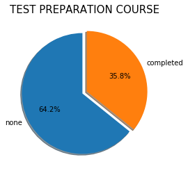

```python
test = result['TEST PREPARATION COURSE'].value_counts()
labels = result["TEST PREPARATION COURSE"].unique()
plt.pie(test,labels=labels,autopct="%1.1f%%",shadow=True,explode=(0.04,0.04),startangle=90)
plt.title('TEST PREPARATION COURSE',fontsize=15)
plt.show()
```

```python
tpc = result.groupby("TEST PREPARATION COURSE")
tpc.mean()
```

| TEST PREPARATION COURSE | MATH SCORE | READING SCORE | WRITING SCORE | AVERAGE |
| --- | --- | --- | --- | --- |
| completed | 69.695531 | 73.893855 | 74.418994 | 72.669460 |
| none | 64.077882 | 66.534268 | 64.504673 | 65.038941 |

#### We can say that Test Preparation Course has definitely improved the scores of students!

### Now, lets see how Test Preparation Course has helped students in improving their Test Scores, Gender wise

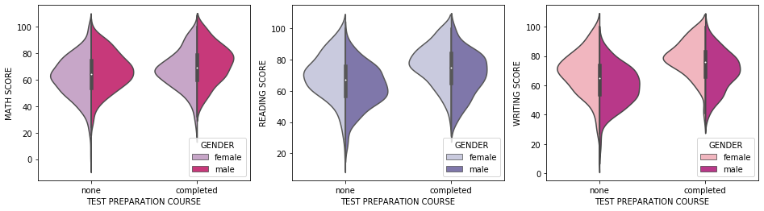

```python
fig, ax = plt.subplots(1, 3, figsize=(16,4))
sns.violinplot(x="TEST PREPARATION COURSE", y='MATH SCORE', data=result,hue='GENDER',split=True,palette='PuRd', ax = ax[0])
sns.violinplot(x="TEST PREPARATION COURSE", y='READING SCORE', data=result,hue='GENDER',split = True,
               palette='Purples', ax = ax[1])
sns.violinplot(x="TEST PREPARATION COURSE", y='WRITING SCORE', data=result,hue='GENDER',split = True,
               palette='RdPu', ax = ax[2])
```

### Lets see how Test Preparation Course has helped to improve the average marks of the students

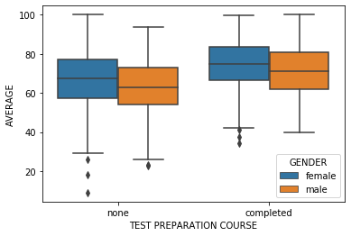

```python
sns.boxplot(x="TEST PREPARATION COURSE", y="AVERAGE", hue = "GENDER", data = result)
```

#### We can see that definitely, Test Preparation Course has helped improve their scores!

### Does a Parent's Level of Education influence the student's performance? Lets find out!

```python
p_edu = result.groupby("PARENTAL LEVEL OF EDUCATION")
p_edu.mean()
```

| PARENTAL LEVEL OF EDUCATION | MATH SCORE | READING SCORE | WRITING SCORE | AVERAGE |
| --- | --- | --- | --- | --- |
| associate's degree | 67.882883 | 70.927928 | 69.896396 | 69.569069 |
| bachelor's degree | 69.389831 | 73.000000 | 73.381356 | 71.923729 |
| high school | 62.137755 | 64.704082 | 62.448980 | 63.096939 |
| master's degree | 69.745763 | 75.372881 | 75.677966 | 73.598870 |
| some college | 67.128319 | 69.460177 | 68.840708 | 68.476401 |
| some high school | 63.497207 | 66.938547 | 64.888268 | 65.108007 |

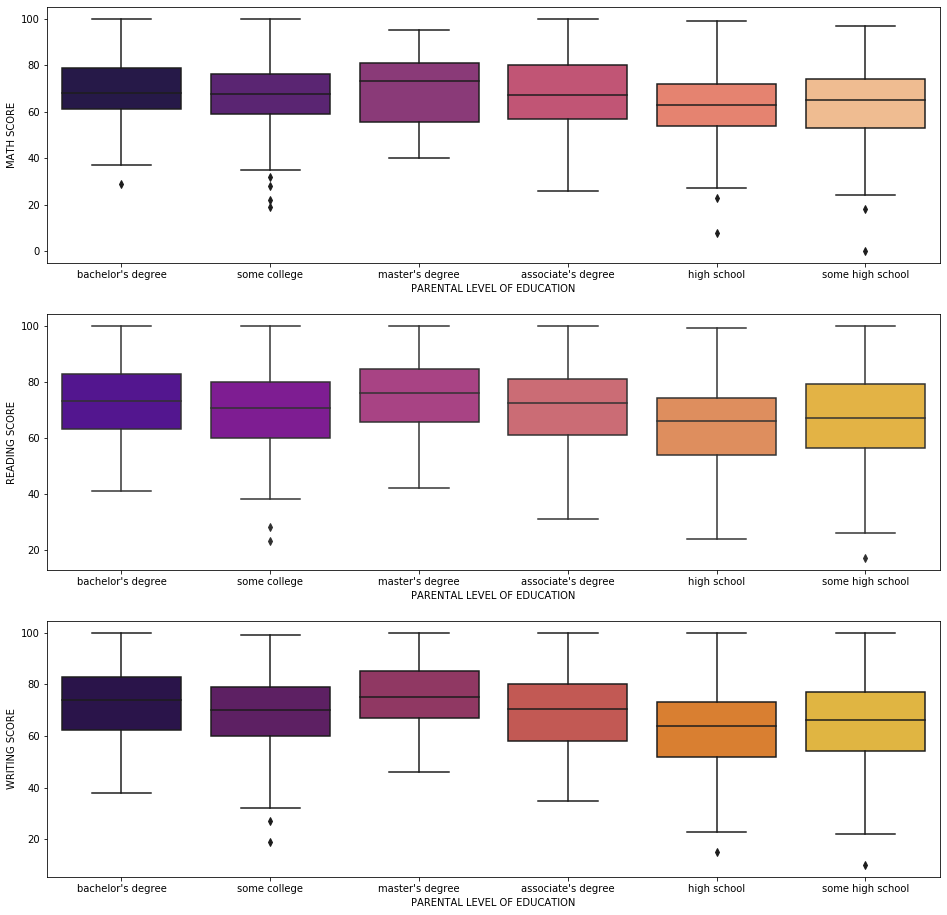

```python
fig, ax = plt.subplots(3, 1, figsize=(16,16))

sns.boxplot(x = 'PARENTAL LEVEL OF EDUCATION', y = 'MATH SCORE', data = result, ax = ax[0], palette = "magma")

sns.boxplot(x = 'PARENTAL LEVEL OF EDUCATION', y = 'READING SCORE', data = result, ax = ax[1], palette = "plasma")

sns.boxplot(x = 'PARENTAL LEVEL OF EDUCATION', y = 'WRITING SCORE', data = result, ax = ax[2], palette = "inferno")
```

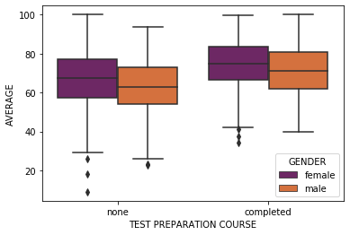

```python
sns.boxplot(x="TEST PREPARATION COURSE", y='AVERAGE', data=result,hue='GENDER', palette='inferno')
```

#### Yeah! Parental Level of Education does improve the scores of students!

### Lets find the count of students belonging to a particular Race/Ethnicity

```python
# Lets find the percentage distribution
(result["RACE/ETHNICITY"].value_counts()/len(result)) * 100
```

```
group C    31.9
group D    26.2
group B    19.0
group E    14.0
group A     8.9
Name: RACE/ETHNICITY, dtype: float64
```

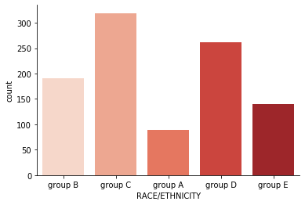

```python
sns.countplot(x='RACE/ETHNICITY', data=result, palette = 'Reds')
sns.despine()
```

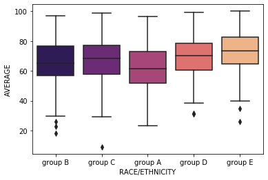

```python
sns.boxplot(x = 'RACE/ETHNICITY', y = 'AVERAGE', data = result, palette = "magma")
```

#### Therefore, we can see that Group E students have a higher average than others!

### Lets see how the distribution Parental Level Of Education varies with Race/Ethnicity

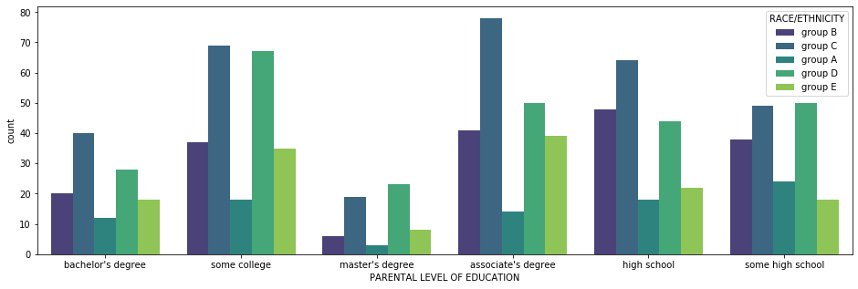

```python
plt.figure(figsize = (16,5))
sns.countplot(x="PARENTAL LEVEL OF EDUCATION", hue="RACE/ETHNICITY", data=result, palette='viridis')
```

### Lets find out the percentage of students who receive standard and reduced Lunch

```python
(result["LUNCH"].value_counts()/len(result)) * 100
```

```
standard        64.5
free/reduced    35.5
Name: LUNCH, dtype: float64
```

[figure not shown]

```python
lunch = result['LUNCH'].value_counts()
labels = result["LUNCH"].unique()
plt.pie(test,labels=labels,autopct="%1.1f%%",shadow=True,explode=(0.04,0.04),startangle=90)
plt.title('LUNCH DISTRIBUTION',fontsize=15)
plt.show()
```

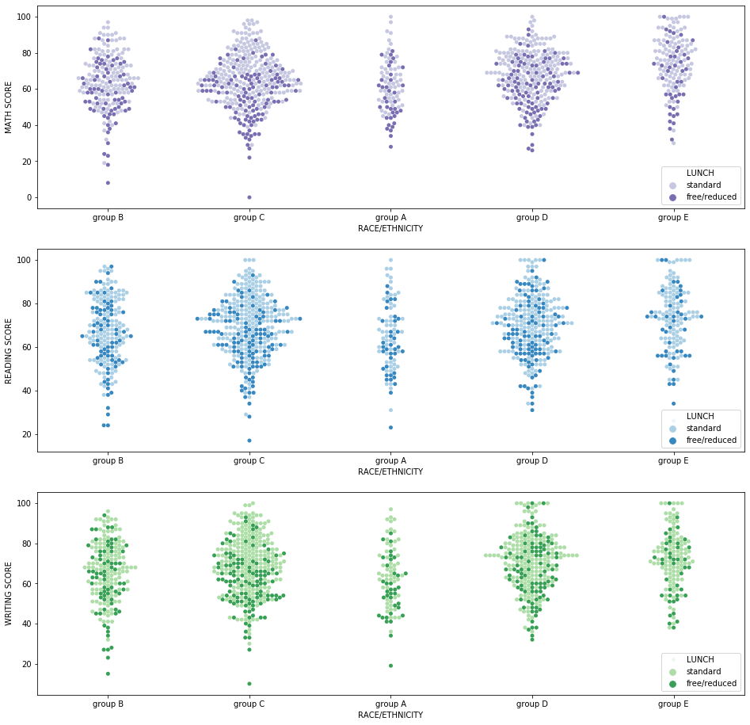

```python
# Plotting the figures
fig, ax = plt.subplots(3, 1, figsize=(16,16))
sns.swarmplot(x="RACE/ETHNICITY", y='MATH SCORE', data=result,hue='LUNCH',palette='Purples', ax = ax[0])
sns.swarmplot(x="RACE/ETHNICITY", y='READING SCORE', data=result,hue='LUNCH', palette='Blues', ax = ax[1])
sns.swarmplot(x="RACE/ETHNICITY", y='WRITING SCORE', data=result,hue='LUNCH', palette='Greens', ax = ax[2])
```

### Lets see if Lunch affects the scores of students

```python
p_edu = result.groupby("LUNCH")
p_edu.mean()
```

| LUNCH | MATH SCORE | READING SCORE | WRITING SCORE | AVERAGE |
| --- | --- | --- | --- | --- |
| free/reduced | 58.921127 | 64.653521 | 63.022535 | 62.199061 |
| standard | 70.034109 | 71.654264 | 70.823256 | 70.837209 |

#### Students with Standard Lunch seem to score better than those with Free/Reduced Lunch !

### Lets see how type of Lunch differs due to Race/Ethnicity

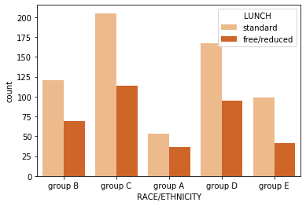

```python
sns.countplot(x="RACE/ETHNICITY", hue="LUNCH", data=result, palette='Oranges')
```

#### Group C receives the majority of free/reduced Lunches while Group A receives the least

### Is Free/Reduced Lunch Gender Biased? Lets find out!

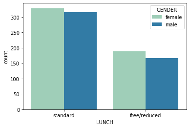

```python
sns.countplot(x="LUNCH", data=result,hue = 'GENDER', palette='YlGnBu')
```

#### The number of females receiving Standard or Free/Reduced Lunch is higher in both the cases!